# Econometria Aplicada à Finanças Aula 8

Influência, regressão robusta e regressão quantílica

Autor

Jonathan Vargas Silva

# Introdução

Este roteiro acompanha a execução dos códigos da Aula 8. Execute os blocos na ordem apresentada.

# Diagnósticos de influência

Carregue os dados, mantenha as observações completas e estime o modelo.

**Código**

```r
# Carrega os dados utilizados nos diagnósticos de influência.
data("PublicSchools", package = "sandwich")

# Remove a observação incompleta e estima a regressão linear simples.
ps <- na.omit(PublicSchools)
ps_lm <- lm(Expenditure ~ Income, data = ps)

# Exibe os resultados da regressão estimada.
summary(ps_lm)
```

```
Call:
lm(formula = Expenditure ~ Income, data = ps)

Residuals:
    Min      1Q  Median      3Q     Max
-112.39  -42.15   -6.16   30.63  224.21

Coefficients:
              Estimate Std. Error t value       Pr(>|t|)
(Intercept) -151.26509   64.12183   -2.36          0.022 *
Income         0.06894    0.00835    8.26 0.000000000091 ***
---
Signif. codes:  0 '***' 0.001 '**' 0.01 '*' 0.05 '.' 0.1 ' ' 1

Residual standard error: 61.4 on 48 degrees of freedom
Multiple R-squared:  0.587, Adjusted R-squared:  0.578
F-statistic: 68.2 on 1 and 48 DF,  p-value: 0.0000000000905
```

Obtenha a matriz do modelo e calcule explicitamente a matriz $H$.

**Código**

```r
# Extrai a matriz do modelo construída a partir da fórmula.
X <- model.matrix(ps_lm)

# Exibe as dimensões da matriz do modelo.
dim(X)
```

```
[1] 50  2
```

**Código**

```r
# Exibe os nomes das colunas da matriz do modelo.
colnames(X)
```

```
[1] "(Intercept)" "Income"
```

**Código**

```r
# Calcula a matriz H e extrai seus elementos diagonais.
H <- X %*% solve(crossprod(X)) %*% t(X)
hii_matriz <- diag(H)

# Exibe os primeiros valores da diagonal de H.
head(hii_matriz)
```

```
   Alabama     Alaska    Arizona   Arkansas California   Colorado
  0.054274   0.214373   0.021017   0.057572   0.048493   0.022847
```

Compare a diagonal de $H$ com os valores fornecidos por `hatvalues()`.

**Código**

```r
# Obtém diretamente os valores de alavancagem do modelo.
hii <- hatvalues(ps_lm)

# Exibe os primeiros valores de alavancagem.
head(hii)
```

```
   Alabama     Alaska    Arizona   Arkansas California   Colorado
  0.054274   0.214373   0.021017   0.057572   0.048493   0.022847
```

**Código**

```r
# Verifica a equivalência entre os dois cálculos.
all.equal(hii_matriz, hii)
```

```
[1] TRUE
```

Calcule a referência prática e identifique as observações que a ultrapassam.

**Código**

```r
# Obtém o tamanho da amostra e o número de variáveis explicativas.
n <- nrow(X)
p <- ncol(X) - 1

# Calcula a referência prática para alta alavancagem.
limite_h <- 2 * (p + 1) / n

# Exibe o valor da referência prática.
limite_h
```

```
[1] 0.08
```

**Código**

```r
# Organiza e identifica as observações acima da referência.
alavancagem_ps <- tibble(
  Observação = names(hii),
  Alavancagem = as.numeric(hii)
)

# Mostra as observações acima da referência de alavancagem.
alavancagem_ps |>
  filter(Alavancagem > limite_h) |>
  arrange(desc(Alavancagem))
```

```
# A tibble: 3 × 2
  Observação    Alavancagem
  <chr>               <dbl>
1 Alaska             0.214
2 Washington DC      0.128
3 Mississippi        0.0848
```

Essa referência é uma regra de triagem, não um teste formal nem uma regra de exclusão.

Calcule e compare os resíduos padronizados e studentizados externamente.

**Código**

```r
# Calcula os dois tipos de resíduos usados no diagnóstico.
rpad <- rstandard(ps_lm)
rstud <- rstudent(ps_lm)

# Exibe os primeiros valores dos dois tipos de resíduos.
head(
  cbind(
    Padronizado = rpad,
    Studentizado = rstud
  )
)
```

```
           Padronizado Studentizado
Alabama    -0.07360471  -0.07283807
Alaska      4.11917243   5.06933614
Arizona    -0.29771944  -0.29487426
Arkansas    0.00027532   0.00027243
California -1.19934475  -1.20497809
Colorado    0.85143573   0.84895519
```

Aplique a referência prática para resíduos studentizados incomuns.

**Código**

```r
# Organiza os resíduos studentizados por observação.
residuos_studentizados <- tibble(
  Observação = names(rstud),
  `Resíduo studentizado` = as.numeric(rstud)
)

# Identifica as observações para as quais |r_i^*| ultrapassa 2.
residuos_studentizados |>
  filter(abs(`Resíduo studentizado`) > 2) |>
  arrange(desc(abs(`Resíduo studentizado`)))
```

```
# A tibble: 2 × 2
  Observação    `Resíduo studentizado`
  <chr>                          <dbl>
1 Alaska                          5.07
2 Washington DC                  -2.01
```

Calcule DFBETAS e examine a sensibilidade de cada coeficiente.

**Código**

```r
# Calcula DFBETAS e sua referência prática.
dfbetas_ps <- dfbetas(ps_lm)
limite_dfbetas <- 2 / sqrt(n)

# Exibe a referência prática para DFBETAS.
limite_dfbetas
```

```
[1] 0.28284
```

**Código**

```r
# Mostra as observações sinalizadas em pelo menos um coeficiente.
dfbetas_ps[
  apply(abs(dfbetas_ps) > limite_dfbetas, 1, any),
  ,
  drop = FALSE
]
```

```
              (Intercept)   Income
Alaska           -2.38873  2.52151
Nevada            0.34466 -0.38646
Utah              0.29543 -0.26062
Washington DC     0.65748 -0.70514
```

**Código**

```r
# Compara os casos destacados na aula.
dfbetas_ps[c("Alaska", "Utah"), ]
```

```
       (Intercept)   Income
Alaska    -2.38873  2.52151
Utah       0.29543 -0.26062
```

Uma observação pode ser influente para um coeficiente e não para outro.

Calcule DFFITS e identifique as observações sinalizadas.

**Código**

```r
# Calcula DFFITS e sua referência prática.
dffits_ps <- dffits(ps_lm)
limite_dffits <- 2 * sqrt((p + 1) / n)

# Exibe a referência prática para DFFITS.
limite_dffits
```

```
[1] 0.4
```

**Código**

```r
# Identifica as observações que ultrapassam a referência.
dffits_ps[abs(dffits_ps) > limite_dffits]
```

```
       Alaska        Nevada Washington DC
      2.64806      -0.47864      -0.76783
```

Reúna os diagnósticos dos quatro casos usados na aula.

**Código**

```r
# Organiza os diagnósticos calculados para todas as observações.
diagnosticos_ps <- tibble(
  Observação = rownames(ps),
  `Resíduo studentizado` = as.numeric(rstud),
  Alavancagem = as.numeric(hii),
  `DFBETAS: intercepto` = dfbetas_ps[, "(Intercept)"],
  `DFBETAS: Income` = dfbetas_ps[, "Income"],
  DFFITS = as.numeric(dffits_ps)
)

# Seleciona os quatro casos usados para comparar os diagnósticos.
casos_ps <- diagnosticos_ps |>
  filter(Observação %in% c("Alaska", "Mississippi", "Nevada", "Utah")) |>
  slice(match(c("Alaska", "Mississippi", "Nevada", "Utah"), Observação))

# Exibe os diagnósticos dos quatro casos selecionados.
casos_ps |>
  mutate(across(where(is.numeric), ~ sprintf("%.4f", .x))) |>
  knitr::kable(
    col.names = c(
      "Observação",
      "$r_i^*$",
      "$h_{ii}$",
      "DFBETAS $\\beta_0$",
      "DFBETAS `Income`",
      "DFFITS"
    ),
    align = c("l", rep("c", 5)),
    escape = FALSE
  )
```

| Observação | $r_i^*$ | $h_{ii}$ | DFBETAS $\beta_0$ | DFBETAS `Income` | DFFITS |
| --- | --- | --- | --- | --- | --- |
| Alaska | 5.0693 | 0.2144 | -2.3887 | 2.5215 | 2.6481 |
| Mississippi | 0.2500 | 0.0848 | 0.0709 | -0.0665 | 0.0761 |
| Nevada | -1.9385 | 0.0575 | 0.3447 | -0.3865 | -0.4786 |
| Utah | 1.9055 | 0.0380 | 0.2954 | -0.2606 | 0.3787 |

**Observe:** resíduo incomum, alta alavancagem e influência são características relacionadas, mas distintas. As referências servem para investigação, não para exclusão automática.

Faça a análise de sensibilidade retirando Alaska.

**Código**

```r
# Remove Alaska da amostra.
ps_sem_alaska <- ps |>
  as_tibble(rownames = "Observação") |>
  filter(Observação != "Alaska")

# Reestima o modelo sem Alaska.
ps_lm_sem_alaska <- lm(
  Expenditure ~ Income,
  data = ps_sem_alaska
)

# Compara os coeficientes estimados com e sem Alaska.
cbind(
  `Amostra completa` = coef(ps_lm),
  `Sem Alaska` = coef(ps_lm_sem_alaska)
)
```

```
            Amostra completa Sem Alaska
(Intercept)      -151.265090 -26.804488
Income              0.068939   0.051831
```

Reproduza graficamente as duas retas ajustadas.

**Código**

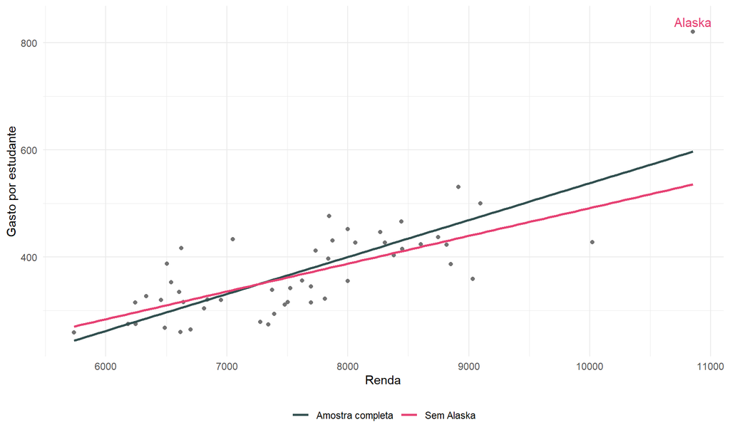

```r
# Prepara os dados e a grade de valores para as duas retas.
ps_grafico <- tibble::rownames_to_column(ps, "Observação")

grade_income <- tibble(
  Income = seq(
    min(ps$Income),
    max(ps$Income),
    length.out = 100
  )
)

# Calcula os valores ajustados com e sem Alaska.
grade_ps <- bind_rows(
  tibble(
    Income = grade_income$Income,
    Expenditure = predict(ps_lm, newdata = grade_income),
    Modelo = "Amostra completa"
  ),
  tibble(
    Income = grade_income$Income,
    Expenditure = predict(ps_lm_sem_alaska, newdata = grade_income),
    Modelo = "Sem Alaska"
  )
)

# Compara as duas retas ajustadas.
ggplot(ps_grafico, aes(x = Income, y = Expenditure)) +
  geom_point(color = "grey45") +
  geom_text(
    data = filter(ps_grafico, Observação == "Alaska"),
    aes(label = Observação),
    nudge_y = 18,
    color = "#e64173",
    size = 4
  ) +
  geom_line(
    data = grade_ps,
    aes(color = Modelo),
    linewidth = 1
  ) +
  scale_color_manual(values = c("#314f4f", "#e64173")) +
  labs(
    x = "Renda",
    y = "Gasto por estudante",
    color = NULL
  ) +
  theme_minimal() +
  theme(legend.position = "bottom")
```

# Regressão robusta

Carregue `OECDGrowth` e estime a mesma especificação por MQO e por `lmrob()`.

**Código**

```r
# Carrega os dados usados no exemplo.
data("OECDGrowth", package = "AER")

# Define a especificação comum aos dois procedimentos.
formula_solow <-
  log(gdp85 / gdp60) ~ log(gdp60) + log(invest) + log(popgrowth + 0.05)

# Estima o modelo por mínimos quadrados ordinários.
solow_lm <- lm(formula_solow, data = OECDGrowth)

# Estima a mesma especificação com o procedimento robusto.
solow_robusta <- robustbase::lmrob(
  formula_solow,
  data = OECDGrowth,
  setting = "KS2014"
)
```

MQO e `lmrob()` usam a mesma especificação; o procedimento de estimação é que muda.

Examine os resultados e os intervalos de confiança do ajuste robusto.

**Código**

```r
# Exibe coeficientes, erros-padrão, estatísticas t e valores-p.
summary(solow_robusta)
```

```
Call:
robustbase::lmrob(formula = formula_solow, data = OECDGrowth, setting = "KS2014")
 \--> method = "SMDM"
Residuals:
     Min       1Q   Median       3Q      Max
-0.14996 -0.03247 -0.00339  0.03791  0.39006

Coefficients:
                      Estimate Std. Error t value  Pr(>|t|)
(Intercept)             2.1822     0.9175    2.38     0.029 *
log(gdp60)             -0.3226     0.0497   -6.49 0.0000042 ***
log(invest)             0.4977     0.1838    2.71     0.014 *
log(popgrowth + 0.05)  -0.7164     0.2549   -2.81     0.012 *
---
Signif. codes:  0 '***' 0.001 '**' 0.01 '*' 0.05 '.' 0.1 ' ' 1

Robust residual standard error: 0.115
Multiple R-squared:  0.755, Adjusted R-squared:  0.714
Convergence in 13 IRWLS iterations

Robustness weights:
 16 weights are ~= 1. The remaining 6 ones are
     Canada         USA       Japan      Norway      Turkey New Zealand
      0.655       0.992       0.274       0.996       0.974       0.960
Algorithmic parameters:
      tuning.chi1       tuning.chi2       tuning.chi3       tuning.chi4
 -0.5000000000000   1.5000000000000                NA   0.5000000000000
               bb       tuning.psi1       tuning.psi2       tuning.psi3
  0.5000000000000  -0.5000000000000   1.5000000000000   0.9500000000000
      tuning.psi4        refine.tol           rel.tol         scale.tol
               NA   0.0000001000000   0.0000001000000   0.0000000001000
        solve.tol          zero.tol       eps.outlier             eps.x
  0.0000001000000   0.0000000001000   0.0045454545455   0.0000000000176
warn.limit.reject warn.limit.meanrw
  0.5000000000000   0.5000000000000
     nResample         max.it       best.r.s       k.fast.s          k.max
          1000            500             20              2           2000
   maxit.scale      trace.lev            mts     compute.rd      numpoints
           200              0           1000              0             10
fast.s.large.n
          2000
              setting                   psi           subsampling
             "KS2014"                 "lqq"         "nonsingular"
                  cov compute.outlier.stats
            ".vcov.w"                "SMDM"
seed : int(0)
```

**Código**

```r
# Calcula os intervalos de confiança de 95%.
confint(solow_robusta)
```

```
                         2.5 %   97.5 %
(Intercept)            0.25451  4.10984
log(gdp60)            -0.42692 -0.21818
log(invest)            0.11145  0.88386
log(popgrowth + 0.05) -1.25184 -0.18087
```

Compare os coeficientes estimados pelos dois procedimentos.

**Código**

```r
# Organiza os coeficientes em uma única tabela.
comparacao_coeficientes <- data.frame(
  Termo = names(coef(solow_lm)),
  MQO = unname(coef(solow_lm)),
  `lmrob (KS2014)` = unname(coef(solow_robusta)),
  check.names = FALSE
)

# Exibe os coeficientes estimados pelos dois procedimentos.
comparacao_coeficientes
```

```
                  Termo      MQO lmrob (KS2014)
1           (Intercept)  2.97590        2.18218
2            log(gdp60) -0.34286       -0.32255
3           log(invest)  0.65011        0.49765
4 log(popgrowth + 0.05) -0.57302       -0.71635
```

Observe como os pesos robustos modificam a contribuição das observações.

**Código**

```r
# Extrai e ordena os pesos de robustez.
pesos_robustos <- weights(solow_robusta, type = "robustness")

# Exibe as quatro menores ponderações.
round(head(sort(pesos_robustos), 4), 3)
```

```
      Japan      Canada New Zealand      Turkey
      0.274       0.655       0.960       0.974
```

Pesos menores indicam maior redução da contribuição da observação no ajuste robusto. O peso não é probabilidade nem regra de exclusão.

# Regressão quantílica

Importe a planilha e construa os retornos excedentes da Ford e do S&P 500.

**Código**

```r
# Localiza e importa a planilha usada na aula.
path_capm <- here::here("data/raw/capm.xls")
dados_capm <- readxl::read_xls(path_capm)

# Calcula os retornos logarítmicos mensais em porcentagem.
dados_capm_retornos <- dados_capm |>
  mutate(
    ret_sp500 = c(NA, 100 * diff(log(SANDP))),
    ret_ford = c(NA, 100 * diff(log(FORD)))
  )

# Converte a taxa livre de risco para a base mensal e calcula os retornos excedentes.
dados_capm_retexc <- dados_capm_retornos |>
  mutate(
    ustb3m = USTB3M / 12,
    retexc_sp500 = ret_sp500 - ustb3m,
    retexc_ford = ret_ford - ustb3m
  ) |>
  drop_na()
```

Estime o CAPM por MQO para descrever a média condicional.

**Código**

```r
# Estima o CAPM por mínimos quadrados ordinários.
capm_ford <- lm(
  retexc_ford ~ retexc_sp500,
  data = dados_capm_retexc
)

# Exibe os resultados do CAPM estimado por MQO.
summary(capm_ford)
```

```
Call:
lm(formula = retexc_ford ~ retexc_sp500, data = dados_capm_retexc)

Residuals:
   Min     1Q Median     3Q    Max
-50.73  -5.03  -1.08   3.48  65.15

Coefficients:
             Estimate Std. Error t value            Pr(>|t|)
(Intercept)    -0.956      0.793   -1.21                0.23
retexc_sp500    1.890      0.192    9.86 <0.0000000000000002 ***
---
Signif. codes:  0 '***' 0.001 '**' 0.01 '*' 0.05 '.' 0.1 ' ' 1

Residual standard error: 11 on 191 degrees of freedom
Multiple R-squared:  0.337, Adjusted R-squared:  0.334
F-statistic: 97.3 on 1 and 191 DF,  p-value: <0.0000000000000002
```

Estime a regressão da mediana condicional.

**Código**

```r
# Estima a mediana condicional do retorno excedente da Ford.
rq_ford_mediana <- quantreg::rq(
  retexc_ford ~ retexc_sp500,
  data = dados_capm_retexc
)

# Exibe os resultados da regressão da mediana.
summary(rq_ford_mediana)
```

```
Call: quantreg::rq(formula = retexc_ford ~ retexc_sp500, data = dados_capm_retexc)

tau: [1] 0.5

Coefficients:
             coefficients lower bd upper bd
(Intercept)  -1.48968     -2.37032 -0.54627
retexc_sp500  1.43846      1.06695  1.83852
```

Quando `tau` não é informado, `rq()` utiliza `tau = 0.50`.

Estime o CAPM nos nove decis.

**Código**

```r
# Estima os quantis condicionais de 0,10 a 0,90.
rq_ford_decis <- quantreg::rq(
  retexc_ford ~ retexc_sp500,
  data = dados_capm_retexc,
  tau = seq(0.1, 0.9, 0.1)
)

# Exibe os resultados das regressões estimadas nos nove decis.
summary(rq_ford_decis)
```

```
Call: quantreg::rq(formula = retexc_ford ~ retexc_sp500, tau = seq(0.1,
    0.9, 0.1), data = dados_capm_retexc)

tau: [1] 0.1

Coefficients:
             coefficients lower bd upper bd
(Intercept)  -11.9291     -13.0959  -9.4002
retexc_sp500   2.3404       1.2091   2.5840

Call: quantreg::rq(formula = retexc_ford ~ retexc_sp500, tau = seq(0.1,
    0.9, 0.1), data = dados_capm_retexc)

tau: [1] 0.2

Coefficients:
             coefficients lower bd upper bd
(Intercept)  -7.3496      -8.7416  -6.0859
retexc_sp500  1.8044       1.3317   2.0607

Call: quantreg::rq(formula = retexc_ford ~ retexc_sp500, tau = seq(0.1,
    0.9, 0.1), data = dados_capm_retexc)

tau: [1] 0.3

Coefficients:
             coefficients lower bd upper bd
(Intercept)  -4.8783      -5.9999  -4.0628
retexc_sp500  1.6596       1.4072   2.0448

Call: quantreg::rq(formula = retexc_ford ~ retexc_sp500, tau = seq(0.1,
    0.9, 0.1), data = dados_capm_retexc)

tau: [1] 0.4

Coefficients:
             coefficients lower bd upper bd
(Intercept)  -3.3479      -4.4147  -1.8955
retexc_sp500  1.5005       1.1955   1.8848

```

[output cut: 34 more lines]

```

Coefficients:
             coefficients lower bd upper bd
(Intercept)  4.0013       2.5742   6.2119
retexc_sp500 1.6199       1.1847   2.0255

Call: quantreg::rq(formula = retexc_ford ~ retexc_sp500, tau = seq(0.1,
    0.9, 0.1), data = dados_capm_retexc)

tau: [1] 0.9

Coefficients:
             coefficients lower bd upper bd
(Intercept)  10.45627      7.53227 14.67108
retexc_sp500  1.84733      0.70219  2.28393
```

Cada regressão utiliza toda a amostra. Os valores de `tau` representam quantis condicionais, não subamostras.

Organize os coeficientes estimados nos decis.

**Código**

```r
# Reúne os coeficientes dos nove quantis estimados.
tabela_decis <- tibble(
  tau = seq(0.1, 0.9, 0.1),
  Intercepto = unname(coef(rq_ford_decis)[1, ]),
  Mercado = unname(coef(rq_ford_decis)[2, ])
)

tabela_decis |>
  mutate(across(c(Intercepto, Mercado), ~ round(.x, 3)))
```

```
# A tibble: 9 × 3
    tau Intercepto Mercado
  <dbl>      <dbl>   <dbl>
1   0.1    -11.9      2.34
2   0.2     -7.35     1.80
3   0.3     -4.88     1.66
4   0.4     -3.35     1.50
5   0.5     -1.49     1.44
6   0.6     -0.019    1.30
7   0.7      1.76     1.53
8   0.8      4.00     1.62
9   0.9     10.5      1.85
```

Construa as retas de MQO e dos quantis selecionados.

**Código**

```r
# Estima os três quantis usados na comparação gráfica.
taus_selecionados <- c(0.10, 0.50, 0.90)
rq_ford <- quantreg::rq(
  retexc_ford ~ retexc_sp500,
  tau = taus_selecionados,
  data = dados_capm_retexc
)

# Organiza os coeficientes das quatro retas.
retas_capm <- bind_rows(
  tibble(
    Relação = "MQO",
    Intercepto = unname(coef(capm_ford)[1]),
    Inclinação = unname(coef(capm_ford)[2])
  ),
  tibble(
    Relação = c("tau = 0,10", "tau = 0,50", "tau = 0,90"),
    Intercepto = unname(coef(rq_ford)[1, ]),
    Inclinação = unname(coef(rq_ford)[2, ])
  )
)

# Exibe os coeficientes das quatro retas comparadas.
retas_capm
```

```
# A tibble: 4 × 3
  Relação    Intercepto Inclinação
  <chr>           <dbl>      <dbl>
1 MQO            -0.956       1.89
2 tau = 0,10    -11.9         2.34
3 tau = 0,50     -1.49        1.44
4 tau = 0,90     10.5         1.85
```

Compare graficamente as quatro relações estimadas.

**Código**

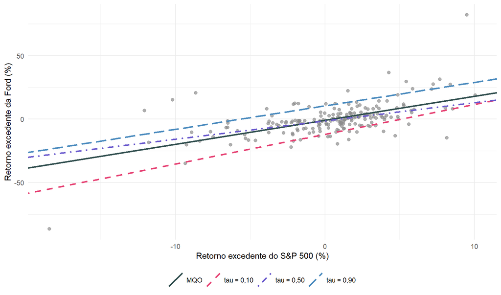

```r
# Representa os dados e as retas estimadas na mesma figura.
ggplot(
  dados_capm_retexc,
  aes(x = retexc_sp500, y = retexc_ford)
) +
  geom_point(color = "grey55", alpha = 0.7, size = 1.8) +
  geom_abline(
    data = retas_capm,
    aes(
      intercept = Intercepto,
      slope = Inclinação,
      color = Relação,
      linetype = Relação
    ),
    linewidth = 1
  ) +
  scale_color_manual(
    values = c(
      "MQO" = "#314f4f",
      "tau = 0,10" = "#e64173",
      "tau = 0,50" = "#6a5acd",
      "tau = 0,90" = "#4b8bbe"
    )
  ) +
  scale_linetype_manual(
    values = c(
      "MQO" = "solid",
      "tau = 0,10" = "dashed",
      "tau = 0,50" = "dotdash",
      "tau = 0,90" = "longdash"
    )
  ) +
  labs(
    x = "Retorno excedente do S&P 500 (%)",
    y = "Retorno excedente da Ford (%)",
    color = NULL,
    linetype = NULL
  ) +
  theme_minimal() +
  theme(legend.position = "bottom")
```

Examine como os coeficientes variam ao longo dos quantis.

**Código**

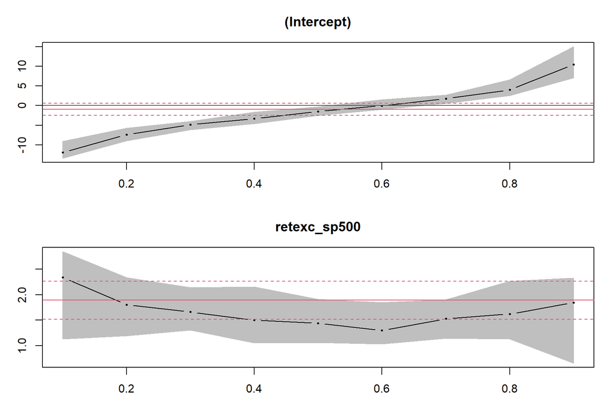

```r
# Calcula os intervalos de 95% e compara os coeficientes quantílicos com o MQO.
plot(
  summary(rq_ford_decis, alpha = 0.05),
  level = 0.95
)
```

**Observe:** o MQO descreve a média condicional, enquanto cada valor de `tau` descreve um quantil condicional da mesma amostra.